# 12_identify_transformation

## 12_identify_transformation

#### Question

1. Let $f(x)=\frac{x^3-3x^2+2}{2}$. Function $g$ is made with a simple transformation (horizontal or vertical shift or stretch with possible reflection). Both functions are graphed below.

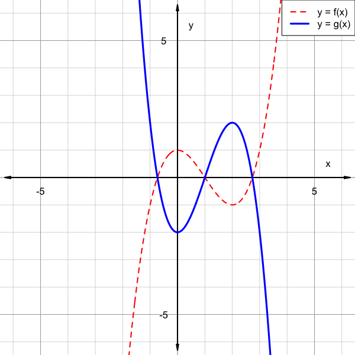

#### Question

2. Let $f(x)=\frac{x^3-3x^2+2}{2}$. Function $g$ is made with a simple transformation (horizontal or vertical shift or stretch with possible reflection). Both functions are graphed below.

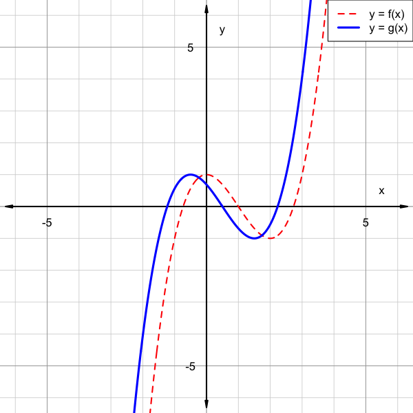

#### Question

3. Let $f(x)=\frac{x^3-3x^2+2}{2}$. Function $g$ is made with a simple transformation (horizontal or vertical shift or stretch with possible reflection). Both functions are graphed below.

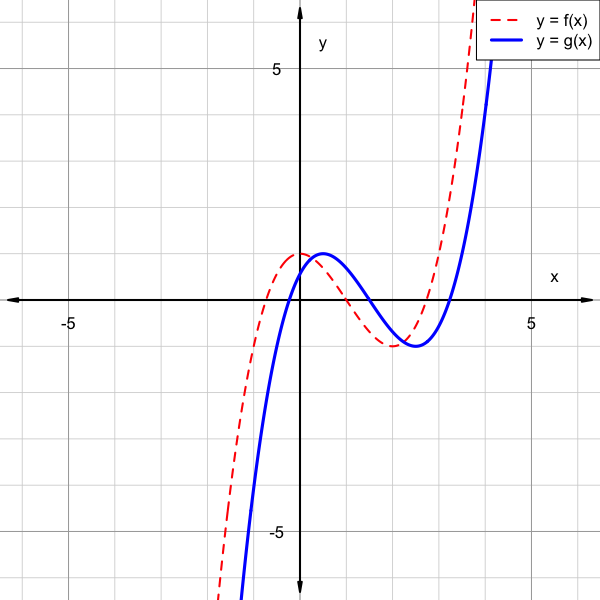

#### Question

4. Let $f(x)=\frac{x^3-3x^2+2}{2}$. Function $g$ is made with a simple transformation (horizontal or vertical shift or stretch with possible reflection). Both functions are graphed below.

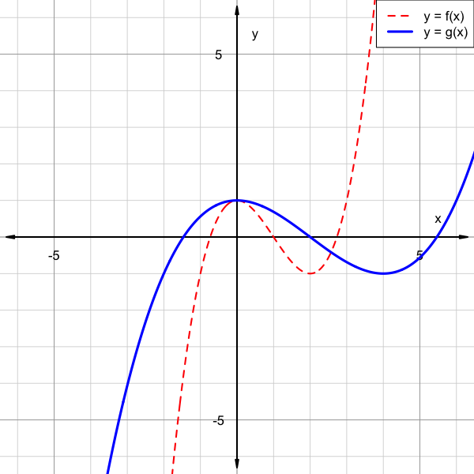

#### Question

5. Let $f(x)=\frac{x^3-3x^2+2}{2}$. Function $g$ is made with a simple transformation (horizontal or vertical shift or stretch with possible reflection). Both functions are graphed below.

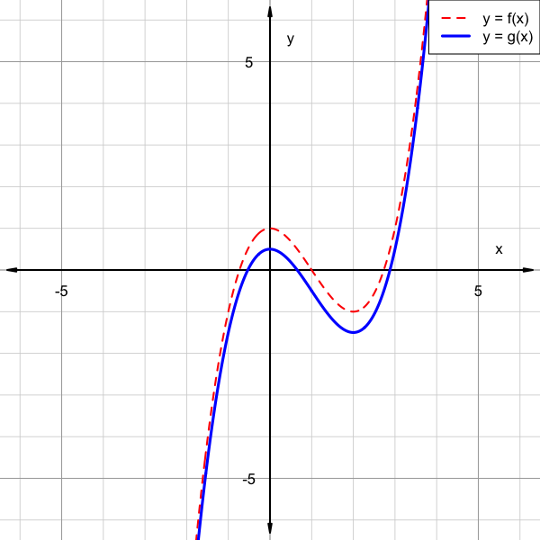

#### Question

6. Let $f(x)=\frac{x^3-3x^2+2}{2}$. Function $g$ is made with a simple transformation (horizontal or vertical shift or stretch with possible reflection). Both functions are graphed below.

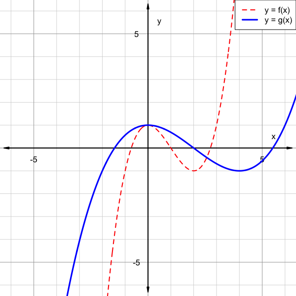

#### Question

7. Let $f(x)=\frac{x^3-3x^2+2}{2}$. Function $g$ is made with a simple transformation (horizontal or vertical shift or stretch with possible reflection). Both functions are graphed below.

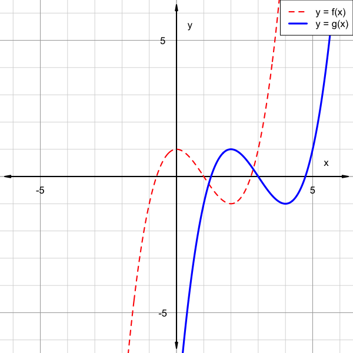

#### Question

8. Let $f(x)=\frac{x^3-3x^2+2}{2}$. Function $g$ is made with a simple transformation (horizontal or vertical shift or stretch with possible reflection). Both functions are graphed below.

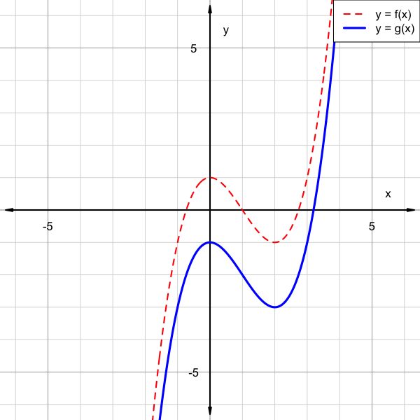